# A5: Carbon Emissions (hello world) Aditi Kesarwani

For this assignment, you will work with global warming-related datasets. These are Scripps CO2 dataset `scripps-co2.csv.bz2` and HadCRUT monthly global temperature `hadcrut-monthly.csv`. The variables you need and a brief description are written below:

**Scripps CO2 Data Set**:

`year` year

`month` month

`co2` (monthly) Mauna Loa observatory CO2 concentration in ppm (particles per million).

**HadCRUT Data Set**:

`year` year

`month` month

`anomaly` global temperature anomaly in the corresponding month, deg C (corresponding to "baseline," you'll see more info later)

```r
library(tidyverse)
```

### Part I: Loading & Inspecting Data

First, let's load the Scripps CO2 data.

```r
scripps <- read.csv("scripps-co2.csv.bz2", sep="\t")
```

1. Use `glimpse()` to make sure the data looks good.

```r
glimpse(scripps)
```

```
Rows: 816
Columns: 11
$ year                      <int> 1958, 1958, 1958, 1958, 1958, 1958, 1958, 19…
$ month                     <int> 1, 2, 3, 4, 5, 6, 7, 8, 9, 10, 11, 12, 1, 2,…
$ date..excel.              <int> 21200, 21231, 21259, 21290, 21320, 21351, 21…
$ date..year.               <dbl> 1958.041, 1958.126, 1958.203, 1958.288, 1958…
$ co2                       <dbl> -99.99, -99.99, 315.71, 317.45, 317.51, -99.…
$ co2..seasonally.adjusted. <dbl> -99.99, -99.99, 314.43, 315.15, 314.69, -99.…
$ co2..seasonal..smoothed.  <dbl> -99.99, -99.99, 316.20, 317.30, 317.88, 317.…
$ co2..smoothed.            <dbl> -99.99, -99.99, 314.90, 314.98, 315.06, 315.…
$ co2..filled.              <dbl> -99.99, -99.99, 315.71, 317.45, 317.51, 317.…
$ co2..adjusted..filled.    <dbl> -99.99, -99.99, 314.43, 315.15, 314.69, 315.…
$ station                   <chr> "MLO", "MLO", "MLO", "MLO", "MLO", "MLO", "M…
```

2. You will only need the variables year, month, and co2. Select these columns and drop everything else. Set it back to the variable `scripps` so that every time `scripps` is called in the future, only these columns are selected.

```r
scripps <- select(scripps, year, month, co2)
```

3. Use `glimpse()` to demonstrate only three columns have been selected.

```r
glimpse(scripps)
```

```
Rows: 816
Columns: 3
$ year  <int> 1958, 1958, 1958, 1958, 1958, 1958, 1958, 1958, 1958, 1958, 1958…
$ month <int> 1, 2, 3, 4, 5, 6, 7, 8, 9, 10, 11, 12, 1, 2, 3, 4, 5, 6, 7, 8, 9…
$ co2   <dbl> -99.99, -99.99, 315.71, 317.45, 317.51, -99.99, 315.87, 314.93, …
```

4. What does a row in this dataset represent? Write a short explanation.

A row in this dataset repersents the year, the month of that year and what the co2 level was that month.

5. How are missing values coded in this dataset? Note, it is not coded as NA! You may need to closely inspect the dataset. Feel free to check out the function `unique()` or just visually inspect the data set!
   - *Note: One way to visually inspect the dataset is to use R Studio. So open R Studio, make a new R file saved in the same place as your dataset. Select Session -> Set Working Directory -> To Source File Location. Then copy in the code `scripps <- read.csv("scripps-co2.csv.bz2", sep="\t")` and any other code you want, and you can us R Studio to view the dataframe.*

NA values are coded as -99.99 in this dataset and 22 of these are present.

6. Now, let's load the HadCRUT data set. Use `glimpse()` to check that it looks good.

```r
hadcrut <- read.csv("hadcrut-monthly.csv")
```

```r
glimpse(hadcrut)
```

```
Rows: 2,112
Columns: 4
$ X       <int> 1, 2, 3, 4, 5, 6, 7, 8, 9, 10, 11, 12, 13, 14, 15, 16, 17, 18,…
$ year    <int> 1850, 1850, 1850, 1850, 1850, 1850, 1850, 1850, 1850, 1850, 18…
$ month   <int> 1, 2, 3, 4, 5, 6, 7, 8, 9, 10, 11, 12, 1, 2, 3, 4, 5, 6, 7, 8,…
$ anomaly <dbl> -0.734, -0.360, -0.627, -0.605, -0.532, -0.352, -0.176, -0.223…
```

8. The first column is not necessary for our purposes since it's just an ID to denote the row column title. Remove it from your data set by only selecting the `year`, `month`, and `anomaly` columns. Set the result back to `hadcrut` so that the dataset now only contains three columns rather than four.

```r
hadcrut <- select(hadcrut, year, month, anomaly)
```

9. Now, use `glimpse()` to make sure that `hadcrut` only contains the three columns you selected above.

```r
glimpse(hadcrut)
```

```
Rows: 2,112
Columns: 3
$ year    <int> 1850, 1850, 1850, 1850, 1850, 1850, 1850, 1850, 1850, 1850, 18…
$ month   <int> 1, 2, 3, 4, 5, 6, 7, 8, 9, 10, 11, 12, 1, 2, 3, 4, 5, 6, 7, 8,…
$ anomaly <dbl> -0.734, -0.360, -0.627, -0.605, -0.532, -0.352, -0.176, -0.223…
```

10. We haven't yet described what the `anomaly` actually describes; all we know is that it is encoded as a double. Search on Google (or whatever browser or AI engine you use), something along the lines of "hadcrut monthly what is a temperature anomaly." What resource did you use, and what did it say? Does it seem to be a reasonable answer?

I did a Google search. It said that the hadcrut anomaly value is the difference between the recorded monthly temperature and the long standing average temperature of that month in a location.

11. Now, check your answer with another INFO 201 student to confirm that your search yielded the same or similar results. Which student did you consult, and did your answers match?

I consulted Sirisha Pyakurel and our answers matched in that a temperature anamoly is the difference between the monthy temperature that's usually recorded and the long standing average for that month in that location.

### Part II: Advanced dplyr

Using the `hadcrut` dataset and what we know about what the `anomaly` column means, let's calculate the proportion of months in each decade that had temperature anomalies above or below the average. This analysis will help illustrate long-term patterns and potential evidence of climate change.

For our data set's purposes, we will have all decades starting from the year 1850 until now. Let's first identify that our data set is good in that every decade has 120 months (10 years * 12 months per year). To do this, we created a new decade column as shown below:

```r
hadcrut <- hadcrut |>
    mutate(decade = year - year %% 10)
```

1. Inspect the equation in the `mutate` statement above closely. What does `%%` mean in the context of the expression above? Write a brief explanation about what this equation does.

The double mod operator returns the remainder in integer division. This code takes the individual year and subtracts the remainder of the year when divided by 10. It basically only leaves the decade marker and rounds all the years to the decade. Like 1981 become 1980 or 1999 because 1990.

Now we have shown the total number of rows:

```r
hadcrut |>
    group_by(decade) |>
    summarize(months = n())
```

A tibble: 18 × 2

| decade <dbl> | months <int> |
| --- | --- |
| 1850 | 120 |
| 1860 | 120 |
| 1870 | 120 |
| 1880 | 120 |
| 1890 | 120 |
| 1900 | 120 |
| 1910 | 120 |
| 1920 | 120 |
| 1930 | 120 |
| 1940 | 120 |
| 1950 | 120 |
| 1960 | 120 |
| 1970 | 120 |
| 1980 | 120 |
| 1990 | 120 |
| 2000 | 120 |
| 2010 | 120 |
| 2020 | 72 |

2. Why does the row for decade "2020" have only 72 months in it? What does this mean?

There's only 72 months in the 2020 decade because the dataset only goes up to 2025 and doesn't have any data for 2026-2029. So up till 2025, the 2020 decade has 72 months in it.

3. Now, filter this decade out of the data frame. Set this filtered data frame to a variable called `hadcrut_subset`. Once you've done this, all of our decades in this newly created data frame will contain 120 months.

```r
hadcrut_subset <- hadcrut |>
    filter(decade != 2020)
glimpse(hadcrut_subset)
```

```
Rows: 2,040
Columns: 4
$ year    <int> 1850, 1850, 1850, 1850, 1850, 1850, 1850, 1850, 1850, 1850, 18…
$ month   <int> 1, 2, 3, 4, 5, 6, 7, 8, 9, 10, 11, 12, 1, 2, 3, 4, 5, 6, 7, 8,…
$ anomaly <dbl> -0.734, -0.360, -0.627, -0.605, -0.532, -0.352, -0.176, -0.223…
$ decade  <dbl> 1850, 1850, 1850, 1850, 1850, 1850, 1850, 1850, 1850, 1850, 18…
```

4. In the HadCRUT dataset, temperature anomalies are measured relative to a standard reference period, defined in our particular data set as the average temperature from the 1960s to the 1980s (asking ChatGPT or other machines would yield different results because we made some changes to how you use the data set for this assignment). Using this reference period, calculate the average value of the anomaly column for the dataset within these decades and store the result in a variable named `avg`. You should be using the `decade` column to achieve this result. Also, because anomalies may be either positive or negative (indicating temperatures above or below the reference average) you should compute `avg` as the mean of the absolute anomalies. Use `as.double()` to convert the data frame into a decimal point value. Print `avg` to show you've done this correctly.

   Hint: to check if a value is in a vector of options (like a set of decades), you can use the %in% operator

   Hint: if you did this correctly, you should see "0.146255555555556" printed. If you're getting a value like "0.138369," then you did the problem incorrectly and should carefully reread the above instructions.

```r
avg <- hadcrut_subset |>
    filter(decade %in% c(1960, 1970, 1980)) |>
    summarize(
        mean_abs_anomaly = mean(abs(anomaly))) |>
    as.double()
print(avg)
```

```
[1] 0.1462556
```

5. You may observe from the `hadcrut` dataset that every row has some anomaly value. So, if we group by the `decade` column and find the proportion of months for each decade where that month's anomaly is more extreme than the average (i.e., the absolute value of the month's anomaly is greater than `avg`), we might see some indication of global warming. Using the `hadcrut` data set, do the following:
- Create a new column `above_avg` that determines whether the row's absolute `anomaly` value is greater than the average you computed earlier.
- Group all rows by the decade.
- Compute the proportion of months for each decade where the month's anomaly value is greater than the standard reference point average. Call the name of this column `prop`, which represents the proportion of months whose anomaly value was more extreme than the average.

```r
hadcrut_subset <- hadcrut_subset |>
    mutate(above_avg = abs(anomaly) > avg) |>
    group_by(decade) |>
    mutate(prop = mean(above_avg))
glimpse(hadcrut_subset)
```

```
Rows: 2,040
Columns: 6
Groups: decade [17]
$ year      <int> 1850, 1850, 1850, 1850, 1850, 1850, 1850, 1850, 1850, 1850, …
$ month     <int> 1, 2, 3, 4, 5, 6, 7, 8, 9, 10, 11, 12, 1, 2, 3, 4, 5, 6, 7, …
$ anomaly   <dbl> -0.734, -0.360, -0.627, -0.605, -0.532, -0.352, -0.176, -0.2…
$ decade    <dbl> 1850, 1850, 1850, 1850, 1850, 1850, 1850, 1850, 1850, 1850, …
$ above_avg <lgl> TRUE, TRUE, TRUE, TRUE, TRUE, TRUE, TRUE, TRUE, TRUE, TRUE, …
$ prop      <dbl> 0.8833333, 0.8833333, 0.8833333, 0.8833333, 0.8833333, 0.883…
```

### Part III: Data Join & ggplot2

1. Let's merge the Scripps and HadCRUT data sets. What variables from each data set would you want to use to merge? Describe the join key.

I would want to merge the year and month columns. The join keys would be year and month.

2. Merge these two data sets and save it to a new variable. Use `glimpse()` to show you did this correctly.

```r
merged_df <-
    left_join(hadcrut_subset, scripps, by = c("year", "month"))
glimpse(merged_df)
```

```
Rows: 2,040
Columns: 7
Groups: decade [17]
$ year      <int> 1850, 1850, 1850, 1850, 1850, 1850, 1850, 1850, 1850, 1850, …
$ month     <int> 1, 2, 3, 4, 5, 6, 7, 8, 9, 10, 11, 12, 1, 2, 3, 4, 5, 6, 7, …
$ anomaly   <dbl> -0.734, -0.360, -0.627, -0.605, -0.532, -0.352, -0.176, -0.2…
$ decade    <dbl> 1850, 1850, 1850, 1850, 1850, 1850, 1850, 1850, 1850, 1850, …
$ above_avg <lgl> TRUE, TRUE, TRUE, TRUE, TRUE, TRUE, TRUE, TRUE, TRUE, TRUE, …
$ prop      <dbl> 0.8833333, 0.8833333, 0.8833333, 0.8833333, 0.8833333, 0.883…
$ co2       <dbl> NA, NA, NA, NA, NA, NA, NA, NA, NA, NA, NA, NA, NA, NA, NA, …
```

3. Do you want to keep all CO2 rows? Do you want to keep all temperature rows? Explain! Note that there is an objectively correct answer for this question.

I don't want to keep the rows in CO2 that have an NA value or the -99.99 values as that will throw off the analysis. Yes, I do want to keep all the temperature rows as include any NAs. Since we merged the two datasets and Scripps started in 1958, but Hadcrut started in 1850, once we take the NAs out we will only have data left starting from 1958.

3. Filter by the rows that you wanted to remove from question 3. Make sure to change your initial merged data set so that it reflects these changes!

```r
merged_df <- merged_df |>
    filter(!is.na(co2), co2 != -99.99)

glimpse(merged_df)
```

```
Rows: 737
Columns: 7
Groups: decade [7]
$ year      <int> 1958, 1958, 1958, 1958, 1958, 1958, 1958, 1958, 1959, 1959, …
$ month     <int> 3, 4, 5, 7, 8, 9, 11, 12, 1, 2, 3, 4, 5, 6, 7, 8, 9, 10, 11,…
$ anomaly   <dbl> 0.006, -0.068, 0.017, -0.018, -0.082, -0.112, -0.037, -0.082…
$ decade    <dbl> 1950, 1950, 1950, 1950, 1950, 1950, 1950, 1950, 1950, 1950, …
$ above_avg <lgl> FALSE, FALSE, FALSE, FALSE, FALSE, FALSE, FALSE, FALSE, FALS…
$ prop      <dbl> 0.3916667, 0.3916667, 0.3916667, 0.3916667, 0.3916667, 0.391…
$ co2       <dbl> 315.71, 317.45, 317.51, 315.87, 314.93, 313.21, 313.33, 314.…
```

4. Make a plot in CO2-temperature anomaly axis. Include the following components.
- Use the temperature anomaly wrt the pre-industrial average. (use the anomaly column)
- Mark all months with dots.
- Mark decades with colors (hint: use `factor(decade)`)
  - You don't have to match our color scheme, but if you want to, we used the color brewer "YlOrRd" (Yellow or Red) palette
- Ensure that the labels are easy to understand.

You should be using `ggplot2` to do this. We added the `tidyverse` library which includes `ggplot`.

If you did this correctly, you should see a graph like the following:

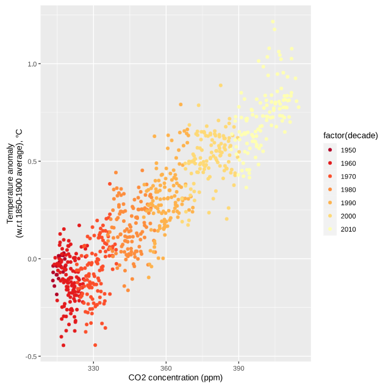

```r
ggplot(data = merged_df) +
    geom_point(mapping = aes(
        x = co2,
        y = anomaly,
        color = factor(decade)
    )) +
    labs(
        x = "CO2 concetration (ppm)",
        y = "Temperature anomaly degrees C"
    )
```

[figure not shown]

5. What is the trend that you notice? Does there seem to be a strong or weak correlation, visually speaking? What could this graph indicate about climate change? Write at least a 50-word statement using full sentences.

The trend that I notice is that as CO2 concentration increases along the horizontal access, the corresponding temperature anamoly rises as well. This shows that over time/ throughout the decades, the temperature anamolies have just increased with rising CO2 levels. There seems to be a strong positive correlation between rising CO2 levles and increasing temperature anamolies shown by the upward slope. This tells us that as CO2 levels have increased in the atmosphere throuhgout the decades, they have increasingly caused disruptions in monthly temperature affecting climate change. We can see that a rise in greenhouse gasses such as CO2 causes extreme temperature changes which affects the overall weather and climate.

### Part IV: Quick Check-In

Approximately how many hours did you spend on this assignment?

I spent about two hours on this assignment.

Which problem(s) did you find to be the most challenging?

The problems that I found the most challenging were calculating teh average anamoly, and creating the prop and above_avg columns in the hadcrut_subset dataset just because the wording was taking me a little longer to understand. But once I understood it/ broke it down it was pretty easy to work out.